```python
import pandas as pd
import numpy as np
from matplotlib import pyplot as plt
import seaborn as sns
%matplotlib inline
import warnings
warnings.filterwarnings('ignore')
```

# The data

Let's start by reading in the incident_event_log.csv file into a pandas dataframe.

```python
data=pd.read_csv("incident_event_log.csv")
```

```python
pd.set_option("display.max_columns",None)
```

```python
data.head()
```

|  | number | incident_state | active | reassignment_count | reopen_count | sys_mod_count | made_sla | caller_id | opened_by | opened_at | sys_created_by | sys_created_at | sys_updated_by | sys_updated_at | contact_type | location | category | subcategory | u_symptom | cmdb_ci | impact | urgency | priority | assignment_group | assigned_to | knowledge | u_priority_confirmation | notify | problem_id | … |
| --- | --- | --- | --- | --- | --- | --- | --- | --- | --- | --- | --- | --- | --- | --- | --- | --- | --- | --- | --- | --- | --- | --- | --- | --- | --- | --- | --- | --- | --- | --- |
| 0 | INC0000045 | New | True | 0 | 0 | 0 | True | Caller 2403 | Opened by 8 | 29/2/2016 01:16 | Created by 6 | 29/2/2016 01:23 | Updated by 21 | 29/2/2016 01:23 | Phone | Location 143 | Category 55 | Subcategory 170 | Symptom 72 | ? | 2 - Medium | 2 - Medium | 3 - Moderate | Group 56 | ? | True | False | Do Not Notify | ? | … |
| 1 | INC0000045 | Resolved | True | 0 | 0 | 2 | True | Caller 2403 | Opened by 8 | 29/2/2016 01:16 | Created by 6 | 29/2/2016 01:23 | Updated by 642 | 29/2/2016 08:53 | Phone | Location 143 | Category 55 | Subcategory 170 | Symptom 72 | ? | 2 - Medium | 2 - Medium | 3 - Moderate | Group 56 | ? | True | False | Do Not Notify | ? | … |
| 2 | INC0000045 | Resolved | True | 0 | 0 | 3 | True | Caller 2403 | Opened by 8 | 29/2/2016 01:16 | Created by 6 | 29/2/2016 01:23 | Updated by 804 | 29/2/2016 11:29 | Phone | Location 143 | Category 55 | Subcategory 170 | Symptom 72 | ? | 2 - Medium | 2 - Medium | 3 - Moderate | Group 56 | ? | True | False | Do Not Notify | ? | … |
| 3 | INC0000045 | Closed | False | 0 | 0 | 4 | True | Caller 2403 | Opened by 8 | 29/2/2016 01:16 | Created by 6 | 29/2/2016 01:23 | Updated by 908 | 5/3/2016 12:00 | Phone | Location 143 | Category 55 | Subcategory 170 | Symptom 72 | ? | 2 - Medium | 2 - Medium | 3 - Moderate | Group 56 | ? | True | False | Do Not Notify | ? | … |
| 4 | INC0000047 | New | True | 0 | 0 | 0 | True | Caller 2403 | Opened by 397 | 29/2/2016 04:40 | Created by 171 | 29/2/2016 04:57 | Updated by 746 | 29/2/2016 04:57 | Phone | Location 165 | Category 40 | Subcategory 215 | Symptom 471 | ? | 2 - Medium | 2 - Medium | 3 - Moderate | Group 70 | Resolver 89 | True | False | Do Not Notify | ? | … |

```python
data.shape
```

```
(141712, 36)
```

```python
data.info()
```

```
<class 'pandas.core.frame.DataFrame'>
RangeIndex: 141712 entries, 0 to 141711
Data columns (total 36 columns):
 #   Column                   Non-Null Count   Dtype
---  ------                   --------------   -----
 0   number                   141712 non-null  object
 1   incident_state           141712 non-null  object
 2   active                   141712 non-null  bool
 3   reassignment_count       141712 non-null  int64
 4   reopen_count             141712 non-null  int64
 5   sys_mod_count            141712 non-null  int64
 6   made_sla                 141712 non-null  bool
 7   caller_id                141712 non-null  object
 8   opened_by                141712 non-null  object
 9   opened_at                141712 non-null  object
```

[output cut: 28 more lines]

```python
data.describe()
```

|  | reassignment_count | reopen_count | sys_mod_count |
| --- | --- | --- | --- |
| count | 141712.000000 | 141712.000000 | 141712.000000 |
| mean | 1.104197 | 0.021918 | 5.080946 |
| std | 1.734673 | 0.207302 | 7.680652 |
| min | 0.000000 | 0.000000 | 0.000000 |
| 25% | 0.000000 | 0.000000 | 1.000000 |
| 50% | 1.000000 | 0.000000 | 3.000000 |
| 75% | 1.000000 | 0.000000 | 6.000000 |
| max | 27.000000 | 8.000000 | 129.000000 |

```python
data.columns
```

```
Index(['number', 'incident_state', 'active', 'reassignment_count',
       'reopen_count', 'sys_mod_count', 'made_sla', 'caller_id', 'opened_by',
       'opened_at', 'sys_created_by', 'sys_created_at', 'sys_updated_by',
       'sys_updated_at', 'contact_type', 'location', 'category', 'subcategory',
       'u_symptom', 'cmdb_ci', 'impact', 'urgency', 'priority',
       'assignment_group', 'assigned_to', 'knowledge',
       'u_priority_confirmation', 'notify', 'problem_id', 'rfc', 'vendor',
       'caused_by', 'closed_code', 'resolved_by', 'resolved_at', 'closed_at'],
      dtype='object')
```

```python
data.columns = ['number', 'incidentstate', 'active', 'reassignmentcount',
       'reopencount', 'sysmodcount', 'madesla', 'callerid', 'openedby',
       'openedat', 'syscreatedby', 'syscreatedat', 'sysupdatedby',
       'sysupdatedat', 'contacttype', 'location', 'category', 'subcategory',
       'usymptom', 'cmdbci', 'impact', 'urgency', 'priority',
       'assignmentgroup', 'assignedto', 'knowledge',
       'upriorityconfirmation', 'notify', 'problemid', 'rfc', 'vendor',
       'causedby', 'closedcode', 'resolvedby', 'resolvedat', 'closedat']
```

```python
Data=data.drop(['madesla','cmdbci','urgency','priority','vendor','resolvedat','closedat','closedcode','causedby'],axis=1)
```

```python
Data.shape
```

```
(141712, 27)
```

```python
Data.head(5)
```

|  | number | incidentstate | active | reassignmentcount | reopencount | sysmodcount | callerid | openedby | openedat | syscreatedby | syscreatedat | sysupdatedby | sysupdatedat | contacttype | location | category | subcategory | usymptom | impact | assignmentgroup | assignedto | knowledge | upriorityconfirmation | notify | problemid | rfc | resolvedby |
| --- | --- | --- | --- | --- | --- | --- | --- | --- | --- | --- | --- | --- | --- | --- | --- | --- | --- | --- | --- | --- | --- | --- | --- | --- | --- | --- | --- |
| 0 | INC0000045 | New | True | 0 | 0 | 0 | Caller 2403 | Opened by 8 | 29/2/2016 01:16 | Created by 6 | 29/2/2016 01:23 | Updated by 21 | 29/2/2016 01:23 | Phone | Location 143 | Category 55 | Subcategory 170 | Symptom 72 | 2 - Medium | Group 56 | ? | True | False | Do Not Notify | ? | ? | Resolved by 149 |
| 1 | INC0000045 | Resolved | True | 0 | 0 | 2 | Caller 2403 | Opened by 8 | 29/2/2016 01:16 | Created by 6 | 29/2/2016 01:23 | Updated by 642 | 29/2/2016 08:53 | Phone | Location 143 | Category 55 | Subcategory 170 | Symptom 72 | 2 - Medium | Group 56 | ? | True | False | Do Not Notify | ? | ? | Resolved by 149 |
| 2 | INC0000045 | Resolved | True | 0 | 0 | 3 | Caller 2403 | Opened by 8 | 29/2/2016 01:16 | Created by 6 | 29/2/2016 01:23 | Updated by 804 | 29/2/2016 11:29 | Phone | Location 143 | Category 55 | Subcategory 170 | Symptom 72 | 2 - Medium | Group 56 | ? | True | False | Do Not Notify | ? | ? | Resolved by 149 |
| 3 | INC0000045 | Closed | False | 0 | 0 | 4 | Caller 2403 | Opened by 8 | 29/2/2016 01:16 | Created by 6 | 29/2/2016 01:23 | Updated by 908 | 5/3/2016 12:00 | Phone | Location 143 | Category 55 | Subcategory 170 | Symptom 72 | 2 - Medium | Group 56 | ? | True | False | Do Not Notify | ? | ? | Resolved by 149 |
| 4 | INC0000047 | New | True | 0 | 0 | 0 | Caller 2403 | Opened by 397 | 29/2/2016 04:40 | Created by 171 | 29/2/2016 04:57 | Updated by 746 | 29/2/2016 04:57 | Phone | Location 165 | Category 40 | Subcategory 215 | Symptom 471 | 2 - Medium | Group 70 | Resolver 89 | True | False | Do Not Notify | ? | ? | Resolved by 81 |

# replacing '?' with nan

```python
Data.replace('?', np.nan,inplace=True)
```

```python
Data.columns
```

```
Index(['number', 'incidentstate', 'active', 'reassignmentcount', 'reopencount',
       'sysmodcount', 'callerid', 'openedby', 'openedat', 'syscreatedby',
       'syscreatedat', 'sysupdatedby', 'sysupdatedat', 'contacttype',
       'location', 'category', 'subcategory', 'usymptom', 'impact',
       'assignmentgroup', 'assignedto', 'knowledge', 'upriorityconfirmation',
       'notify', 'problemid', 'rfc', 'resolvedby'],
      dtype='object')
```

# finding unique values

```python
variable=['number', 'incidentstate', 'active', 'reassignmentcount', 'reopencount',
       'sysmodcount', 'callerid', 'openedby', 'openedat', 'syscreatedby',
       'syscreatedat', 'sysupdatedby', 'sysupdatedat', 'contacttype',
       'location', 'subcategory', 'usymptom', 'impact', 'assignmentgroup',
       'assignedto', 'knowledge', 'upriorityconfirmation', 'notify',
       'problemid', 'rfc', 'resolvedby','category']

for variable in Data:
    print ('\nFrequency of Categories for varible %s'%variable)
    print (Data[variable].value_counts())
```

```
Frequency of Categories for varible number
INC0019396    58
INC0044260    56
INC0005927    46
INC0020718    45
INC0011206    44
              ..
INC0013493     2
INC0030079     2
INC0013496     2
INC0005402     2
INC0011991     2
Name: number, Length: 24918, dtype: int64

Frequency of Categories for varible incidentstate
Active                38716
New                   36407
Resolved              25751
Closed                24985
Awaiting User Info    14642
Awaiting Vendor         707
Awaiting Problem        461
Awaiting Evidence        38
-100                      5
Name: incidentstate, dtype: int64

Frequency of Categories for varible active
True     116726
False     24986
Name: active, dtype: int64

Frequency of Categories for varible reassignmentcount
0     69876
1     37104
2     15097
3      8274
4      4614
5      2595
6      1447
7       985
```

[output cut: 332 more lines]

```
Name: rfc, Length: 181, dtype: int64

Frequency of Categories for varible resolvedby
Resolved by 15     15421
Resolved by 11     12050
Resolved by 103     5360
Resolved by 177     3811
Resolved by 53      3637
                   ...
Resolved by 222        4
Resolved by 17         4
Resolved by 39         3
Resolved by 185        3
Resolved by 48         3
Name: resolvedby, Length: 216, dtype: int64
```

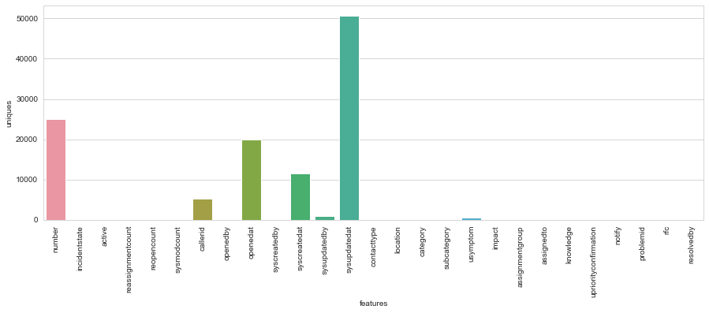

```python
#Plot of unique value of each features
df_unq = Data.nunique().reset_index()
df_unq.columns = ['features', 'uniques']
fig, axes = plt.subplots(figsize=(15,5))
plot = sns.barplot(x='features', y='uniques', data=df_unq)
plot.tick_params(axis='x', rotation=90)
```

# # Exploratory Data Analysis

Let's begin some exploratory data analysis! We'll start by checking out missing data!

# # Missing Data

We can use seaborn to create a simple heatmap to see where we are missing data!#

```python
Data.isnull().sum()
```

```
number                        0
incidentstate                 0
active                        0
reassignmentcount             0
reopencount                   0
sysmodcount                   0
callerid                     29
openedby                   4835
openedat                      0
syscreatedby              53076
syscreatedat              53076
sysupdatedby                  0
sysupdatedat                  0
contacttype                   0
location                     76
category                     78
subcategory                 111
usymptom                  32964
impact                        0
assignmentgroup           14213
assignedto                27496
knowledge                     0
upriorityconfirmation         0
notify                        0
problemid                139417
rfc                      140721
resolvedby                  226
dtype: int64
```

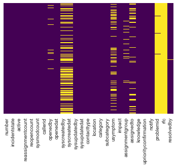

```python
sns.heatmap(Data.isnull(),yticklabels=False,cbar=False,cmap='viridis')
```

Let's continue on by visualizing some more of the data!

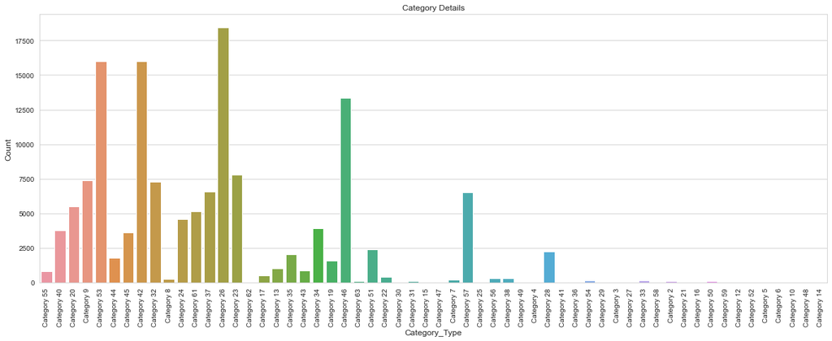

```python
#data visulaization of few features to check the frequency of feature
fig,ax = plt.subplots(figsize=(20,7))
sns.countplot(Data['category'])
plt.title("Category Details")
plt.xlabel("Category_Type", size=12)
plt.ylabel("Count", size=12)
plt.xticks(rotation=90)
plt.show()
```

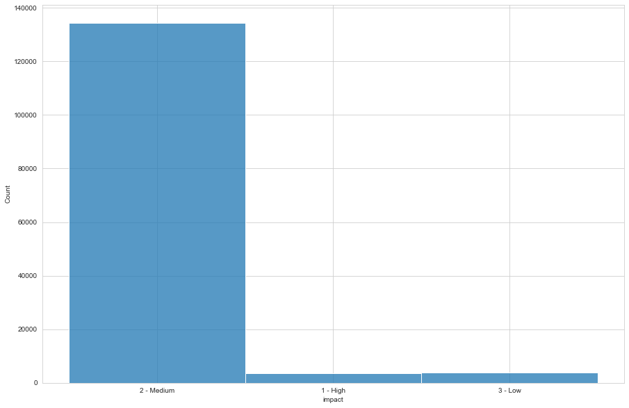

```python
plt.figure(figsize=(15,10))
sns.histplot(data=Data,x='impact')
plt.show()
```

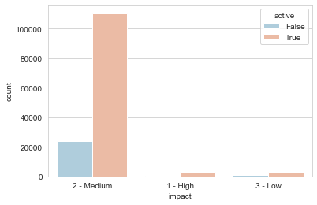

```python
sns.set_style('whitegrid')
sns.countplot(x='impact',hue='active',data=Data,palette='RdBu_r')
```

As We can Observe From above Visualisation and value counts data, Features 'problemid'and rfc' are having very high no. of Missing values so we will exclude these features from further analysis. These features add no value to our data analysis.